# US Flights

Achal Gupta

8 December 2018

### IMPORTING LIBRARIES

Below code will import all the required libraries.

```r
library(Hmisc)
library(sqldf)
library(plyr)
library(dplyr)
library(tidyr)
library(ggplot2)
library(usmap)
```

### LOADING CSV FILE TO VARIABLES

Below code will import the data present in CSV format into R.

```r
USAirlines <- read.csv("US_Airlines.csv")
USAirport <- read.csv("US_Airports.csv")
USAirRecords <- read.csv("US_AirRecords.csv")
```

### DATA CLEANING

#### USAIRPORTS

Identify missing values using summary and remove them

```r
summary(USAirport)
```

```
##    IATA_CODE                              AIRPORT            CITY
##  ABE    :  1   Aberdeen Regional Airport      :  1   Albany    :  2
##  ABI    :  1   Abilene Regional Airport       :  1   Charleston:  2
##  ABQ    :  1   Abraham Lincoln Capital Airport:  1   Chicago   :  2
##  ABR    :  1   Adak Airport                   :  1   Columbia  :  2
##  ABY    :  1   Akron-Canton Regional Airport  :  1   Columbus  :  2
##  ACK    :  1   Albany International Airport   :  1   Houston   :  2
##  (Other):316   (Other)                        :316   (Other)   :310
##      STATE     COUNTRY      LATITUDE       LONGITUDE
##  TX     : 24   USA:322   Min.   :13.48   Min.   :-176.65
##  CA     : 22             1st Qu.:33.65   1st Qu.:-110.84
##  AK     : 19             Median :39.30   Median : -93.40
##  FL     : 17             Mean   :38.98   Mean   : -98.38
##  MI     : 15             3rd Qu.:43.15   3rd Qu.: -82.72
##  NY     : 14             Max.   :71.29   Max.   : -64.80
##  (Other):211             NA's   :3       NA's   :3
```

Found 3 NA values, removing them from the dataset and veridy the data once again

```r
USAirport <- USAirport %>%
  filter(!is.na(LATITUDE))
summary(USAirport)
```

```
##    IATA_CODE                              AIRPORT            CITY
##  ABE    :  1   Aberdeen Regional Airport      :  1   Albany    :  2
##  ABI    :  1   Abilene Regional Airport       :  1   Charleston:  2
##  ABQ    :  1   Abraham Lincoln Capital Airport:  1   Chicago   :  2
##  ABR    :  1   Adak Airport                   :  1   Columbia  :  2
##  ABY    :  1   Akron-Canton Regional Airport  :  1   Columbus  :  2
##  ACK    :  1   Albany International Airport   :  1   Houston   :  2
##  (Other):313   (Other)                        :313   (Other)   :307
##      STATE     COUNTRY      LATITUDE       LONGITUDE
##  TX     : 24   USA:319   Min.   :13.48   Min.   :-176.65
##  CA     : 22             1st Qu.:33.65   1st Qu.:-110.84
##  AK     : 19             Median :39.30   Median : -93.40
##  FL     : 15             Mean   :38.98   Mean   : -98.38
##  MI     : 15             3rd Qu.:43.15   3rd Qu.: -82.72
##  NY     : 13             Max.   :71.29   Max.   : -64.80
##  (Other):211
```

#### USAirRecords

Let’s move on to Data Cleaning for the US Airrecords dataset We will be utilizing Arival Delays for most of the analyses. Hence, we need to remove NA values from ARRIVAL_DELAY. After having a quick look at the data we realized that all Diverted flights have NA values for Delay. Hence, we are removing all diverted flights from dataset

Let’s first check what percentage of flights are diverted.

```r
Diverted <- USAirRecords %>%
  filter(DIVERTED==1 & CANCELLED==0) %>%
  tally()
percent <- (Diverted/520718)*100
percent
```

```
##          n
## 1 0.293441
```

Diverted flights are only 0.29% hence removing rows

```r
USAirRecords <- USAirRecords %>%
  filter(DIVERTED==0)
```

Even after removing Diverted flight we realized that there are still NA values in ARRIVAL_DELAY which are only because of CANCELLED FLIGHT, below summary shows that there are no NA values for non-cancelled flights. Note we are not removing rows for cancelled flights, we will just put a filter in analysis.

```r
summary(USAirRecords %>%
          select (ARRIVAL_DELAY, CANCELLED) %>%
          filter(CANCELLED==0))
```

```
##  ARRIVAL_DELAY        CANCELLED
##  Min.   : -73.000   Min.   :0
##  1st Qu.: -12.000   1st Qu.:0
##  Median :  -4.000   Median :0
##  Mean   :   6.432   Mean   :0
##  3rd Qu.:  10.000   3rd Qu.:0
##  Max.   :1636.000   Max.   :0
```

No changes in variable names or column transformation is required for the below analysis.

### Plot Data and Find point of interest

#### Flight Delays and Number of flights by weekday

Define a data frame with week names.

```r
days <- data.frame(Day=c("Mon","Tue","Wed","Thu","Fri","Sat","Sun"))
```

Calculate total ARRIVAL_DELAY and Flight count for each week day

```r
WeekDay_Delays <- USAirRecords %>%
  group_by(DAY_OF_WEEK) %>%
  dplyr::summarise(AirlineDelay = sum(ARRIVAL_DELAY,na.rm = T))

WeekDay_Count <- USAirRecords %>%
  group_by(DAY_OF_WEEK) %>%
  tally()
```

Merging two data frames to add week day names, corresponding to every week day

```r
WeekDay_Delays <- cbind(WeekDay_Delays, days)
WeekDay_Count <- cbind(WeekDay_Count, days)
```

Bar Graph displaying arrival delays for each week day. We can see that **Wedndesday** have the most delays.

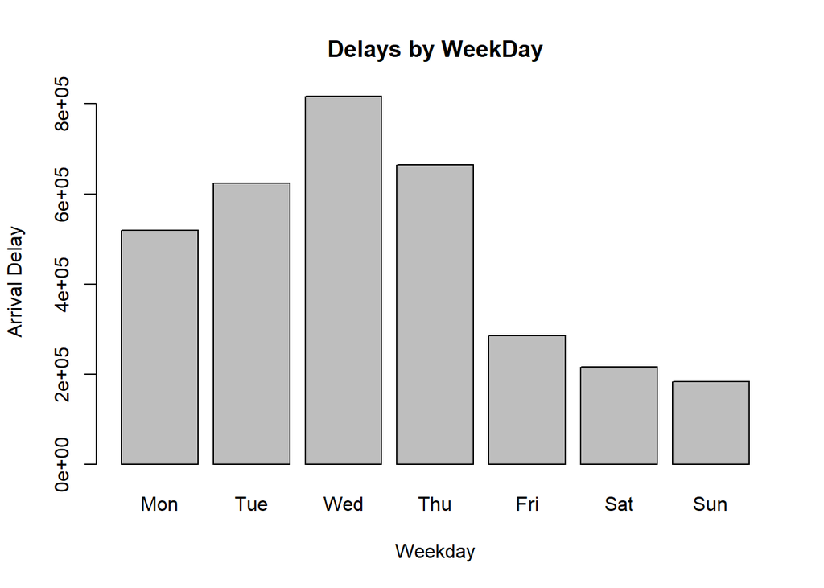

```r
barplot(WeekDay_Delays$AirlineDelay,
        names.arg=WeekDay_Delays$Day,
        main="Delays by WeekDay",
        xlab="Weekday",
        ylab="Arrival Delay")
```

Bar Graph displaying Number of flights for each week day. We can see that **Thursday** have highest flight count.

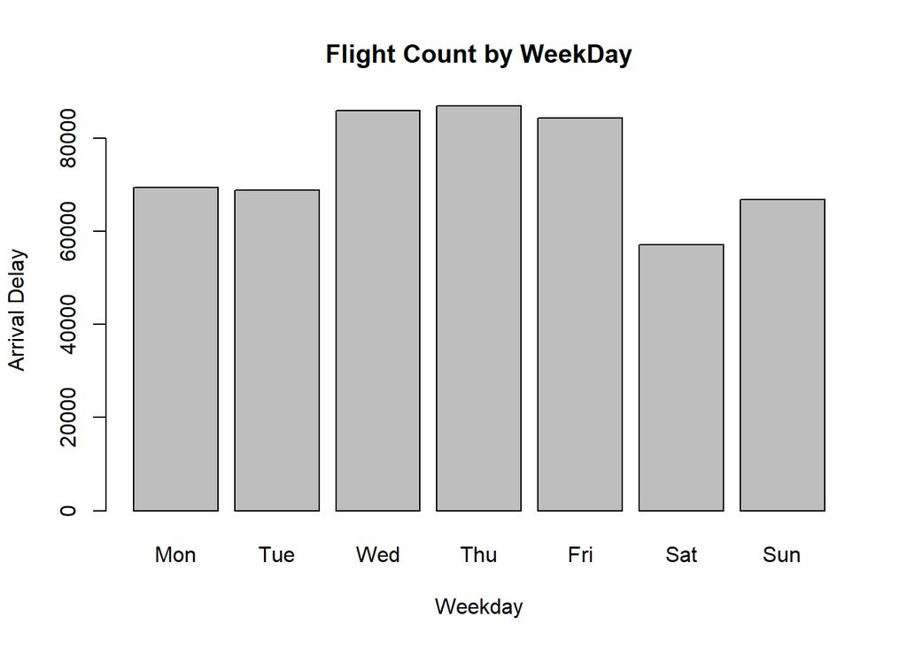

```r
barplot(WeekDay_Count$n,
        names.arg=WeekDay_Count$Day,
        main="Flight Count by WeekDay",
        xlab="Weekday",
        ylab="Arrival Delay")
```

From above two graphs we can see that even though flight count for Wednesday is almost same as Thursday, still delays are more on Wednesdays for some reason.

#### Most frequent cancellation reason

Define a data frame with Cancellation Reasons as given

```r
Reason <- data.frame(Reason=c("Airline/Carrier", "Weather", "National Air System", "Security"))
```

Find out the count of cancelled flights for each reason

```r
CancellationReason <- USAirRecords %>%
  filter(CANCELLED==1) %>%
  group_by(CANCELLATION_REASON) %>%
  tally()
CancellationReason <- cbind(CancellationReason, Reason)

print(c(toString(CancellationReason[which.max(CancellationReason$n),3]),"is the reson for maximum cancellations in US"))
```

```
## [1] "Airline/Carrier"
## [2] "is the reson for maximum cancellations in US"
```

#### Average delay in flight due to Weather in non-cancelled flights

Filter out the flights which got Cancelled and have no weather delays

```r
AvgWeatherDelay <- USAirRecords %>%
  select(FLIGHT_NUMBER, WEATHER_DELAY, CANCELLED) %>%
  filter(CANCELLED==0 & WEATHER_DELAY != 0)
```

Removing outliers in delay that is exception cases, where delay is too high

```r
summary(AvgWeatherDelay)
```

```
##  FLIGHT_NUMBER  WEATHER_DELAY     CANCELLED
##  Min.   :   2   Min.   :  1.0   Min.   :0
##  1st Qu.: 783   1st Qu.: 13.0   1st Qu.:0
##  Median :1592   Median : 26.0   Median :0
##  Mean   :1956   Mean   : 41.5   Mean   :0
##  3rd Qu.:2816   3rd Qu.: 50.0   3rd Qu.:0
##  Max.   :7426   Max.   :836.0   Max.   :0
```

```r
AvgWeatherDelay <- AvgWeatherDelay %>%
  filter(WEATHER_DELAY > 13 & WEATHER_DELAY < 50)
```

Boxplot of the data to analyse the data distribtion.

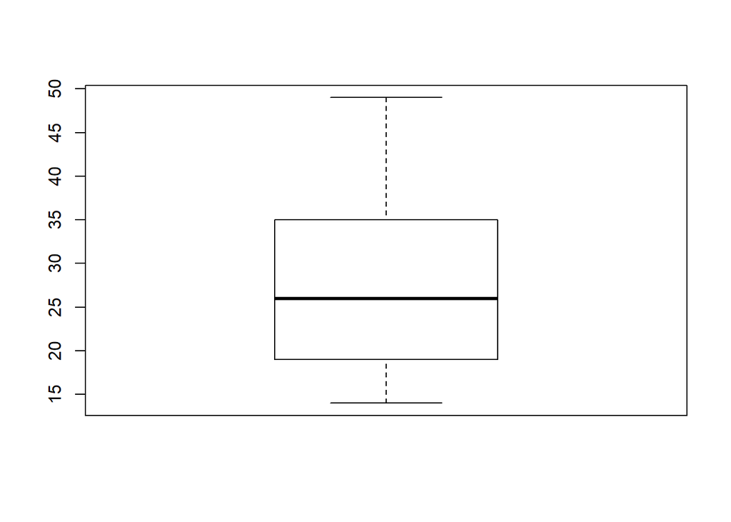

```r
boxplot(AvgWeatherDelay$WEATHER_DELAY)
```

calculating average delay due to weather in general.

```r
print(c("Average delay due to weather is",toString(mean(AvgWeatherDelay$WEATHER_DELAY))))
```

```
## [1] "Average delay due to weather is" "27.7380059970015"
```

#### Find out counties with maximum number of flights flying out

To find out Counties or States in US with maximum flight delays we will use the US Map and plot flight counts on map using colour scale.

Firsty lets plot an empty US Map

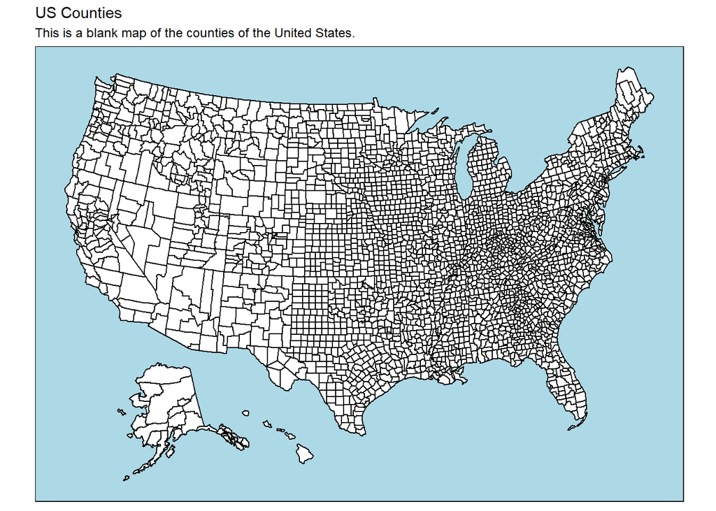

```r
plot_usmap(regions = "counties") +
  labs(title = "US Counties", subtitle = "This is a blank map of the counties of the United States.") +
  theme(panel.background = element_rect(colour = "black", fill = "lightblue"))
```

Create a DF of raw US Map data

```r
FIPS_DF <- usmap::us_map()
```

We will use SQL queries to manipulate data and create required Dataset.

First select STATE code and FIPS code from raw US Map data

```r
FIPS <- sqldf("SELECT DISTINCT abbr, fips
              FROM FIPS_DF
              ")
```

get Flight Counts for each Airport from US Air record dataset

```r
USFlightCount <- sqldf("SELECT ORIGIN_Airport, Count(FLIGHT_NUMBER) CNT
                       FROM USAirRecords
                       Where CANCELLED = 0
                       GROUP BY ORIGIN_Airport"
)
```

Join the FLight Count data set with US Airport data and calculate number of flights per State or County.

```r
USMapVal <- sqldf("SELECT DISTINCT UA.STATE, SUM(UFC.CNT) AS SUM
              FROM USFlightCount UFC
              Left JOin USAirport UA On UFC.ORIGIN_AIRPORT = UA.IATA_CODE
              GROUP BY UA.STATE")
```

Finally join the raw US Map data with FIPS code (required to plot data on map) with the summarized flight count dataset.

```r
USMapFips <- sqldf("SELECT U.*, F.fips
                    FROM USMapVal U
                    JOIN FIPS F On F.abbr = U.STATE
                   ")
```

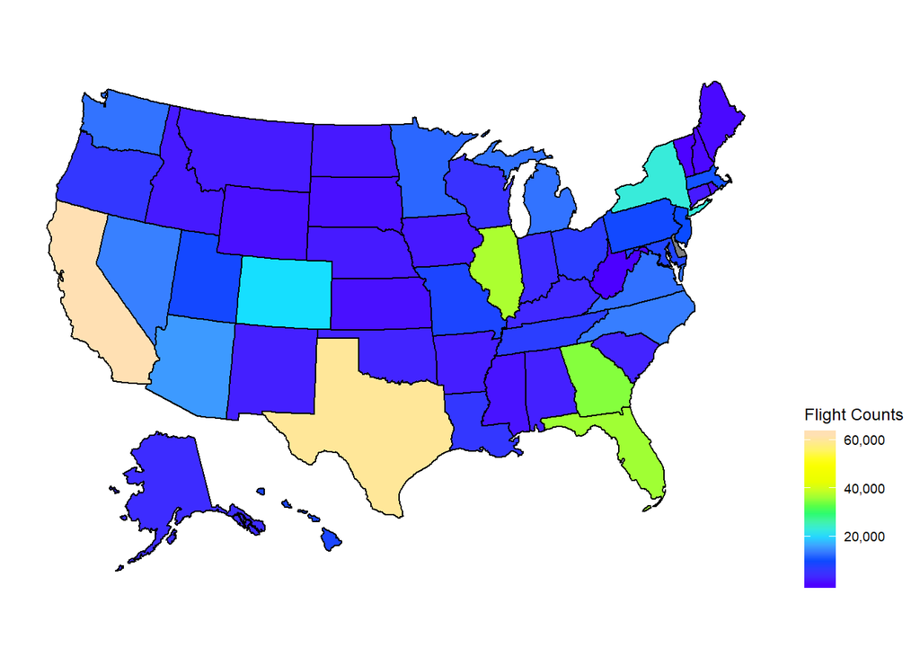

```r
plot_usmap(data=USMapFips, values = "SUM") +
  scale_fill_gradientn( colours = topo.colors(7),
                        name = "Flight Counts", label = scales::comma
  ) + theme(legend.position = "right")
```

### Airlines with most Delays

Calculate sum of delay in arrival for each airline

```r
Airline_Most_Delays <- USAirRecords %>%
  group_by(AIRLINE) %>%
  dplyr::summarise(AirlineDelay = sum(ARRIVAL_DELAY,na.rm = T))
```

Get the airline with maximum delays

```r
MaxDelay <- Airline_Most_Delays[which.max(Airline_Most_Delays$AirlineDelay),1]
print(c("Airline with Maximum Delays is",toString(USAirlines[USAirlines$IATA_CODE== toString(MaxDelay$AIRLINE), "AIRLINE"])))
```

```
## [1] "Airline with Maximum Delays is" "Southwest Airlines Co."
```

Order the data with Asecending order of delay and plot the bargraph of last 10 rows i.e top 10 airlines with most delays

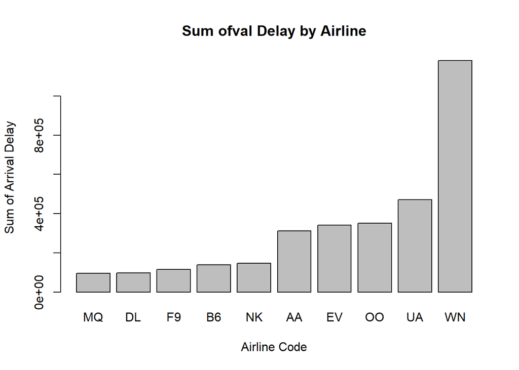

```r
Airline_Most_Delays <- Airline_Most_Delays %>%
  arrange(AirlineDelay)

barplot(tail(Airline_Most_Delays$AirlineDelay,10),
        names.arg=tail(Airline_Most_Delays$AIRLINE,10),
        main="Sum ofval Delay by Airline",
        xlab="Airline Code",
        ylab="Sum of Arrival Delay")
```

### Identify Relation Between Distance and Flying Time

In order to understand the relation betwen Airport distace and flying time we will plot a scatterplot. But first we need to remove outliers from Airtime

```r
summary(USAirRecords$AIR_TIME)
```

```
##    Min. 1st Qu.  Median    Mean 3rd Qu.    Max.    NA's
##     7.0    61.0    95.0   114.4   145.0   639.0    4806
```

```r
USAirRecordsFilt <- USAirRecords %>%
  filter(USAirRecords$AIR_TIME>61.0  )
```

remove outliers from Distance

```r
summary(USAirRecordsFilt$DISTANCE)
```

```
##    Min. 1st Qu.  Median    Mean 3rd Qu.    Max.
##     114     596     867    1045    1303    4983
```

```r
USAirRecordsFilt <- USAirRecordsFilt %>%
  filter(USAirRecordsFilt$DISTANCE>596 & USAirRecordsFilt$DISTANCE<3000)
```

Scatterplot to see the relation between Time And Distance

```r
scatter.smooth(x = USAirRecordsFilt$DISTANCE,y = USAirRecordsFilt$AIR_TIME,
               xlab = "Distance",
               ylab = "Flying Time",
               main = "Distance vs Flying Time"
)
```

[figure not shown]

Further lets see the corelation value

```r
cor(USAirRecordsFilt$DISTANCE, USAirRecordsFilt$AIR_TIME)
```

```
## [1] 0.9840582
```

**Correalation of 0.984 suggests the strong positve realtion**

### Identify the Busiest Route

We will count the number of flights for each pair of Oigin and Destination airport and identify the pair or route with maximum count

```r
Busiest_Route <- USAirRecords %>%
  select(ORIGIN_AIRPORT,DESTINATION_AIRPORT) %>%
  group_by(ORIGIN_AIRPORT,DESTINATION_AIRPORT) %>%
  tally %>%
  arrange(desc(n))
Busiest_Route <- head(Busiest_Route,1)
Busiest_Route
```

```
## # A tibble: 1 x 3
## # Groups:   ORIGIN_AIRPORT [1]
##   ORIGIN_AIRPORT DESTINATION_AIRPORT     n
##   <fct>          <fct>               <int>
## 1 SFO            LAX                  1362
```

```r
print(c("Busiest Route is",toString(USAirport[USAirport$IATA_CODE=="SFO","AIRPORT"]), "to", toString(USAirport[USAirport$IATA_CODE=="LAX","AIRPORT"])))
```

```
## [1] "Busiest Route is"
## [2] "San Francisco International Airport"
## [3] "to"
## [4] "Los Angeles International Airport"
```

### Analysis of choice

#### Prediction of ARRIVAL_DELAY

```r
FLightsData <- sqldf("SELECT ORIGIN_Airport, DESTINATION_AIRPORT, Count(FLIGHT_NUMBER) CNT
                       FROM USAirRecords
                       Where CANCELLED = 0
                       GROUP BY ORIGIN_Airport,DESTINATION_AIRPORT
                       ORDER BY Count(FLIGHT_NUMBER) DESC")

FLightsData <- head(FLightsData,1)
```

```r
Data <- sqldf("SELECT *
                       FROM USAirRecords
                       Where ORIGIN_Airport IN (SELECT ORIGIN_Airport FROM FLightsData)
                       AND DESTINATION_AIRPORT IN (SELECT DESTINATION_AIRPORT FROM FLightsData)")
```

Taking only few coluns on which model is created.

```r
Data_Subset <- Data %>%
  select(ARRIVAL_DELAY, AIR_TIME, WHEELS_OFF, TAXI_IN, SCHEDULED_DEPARTURE, SCHEDULED_ARRIVAL)
```

plotting the correation between the parameters in the dataset

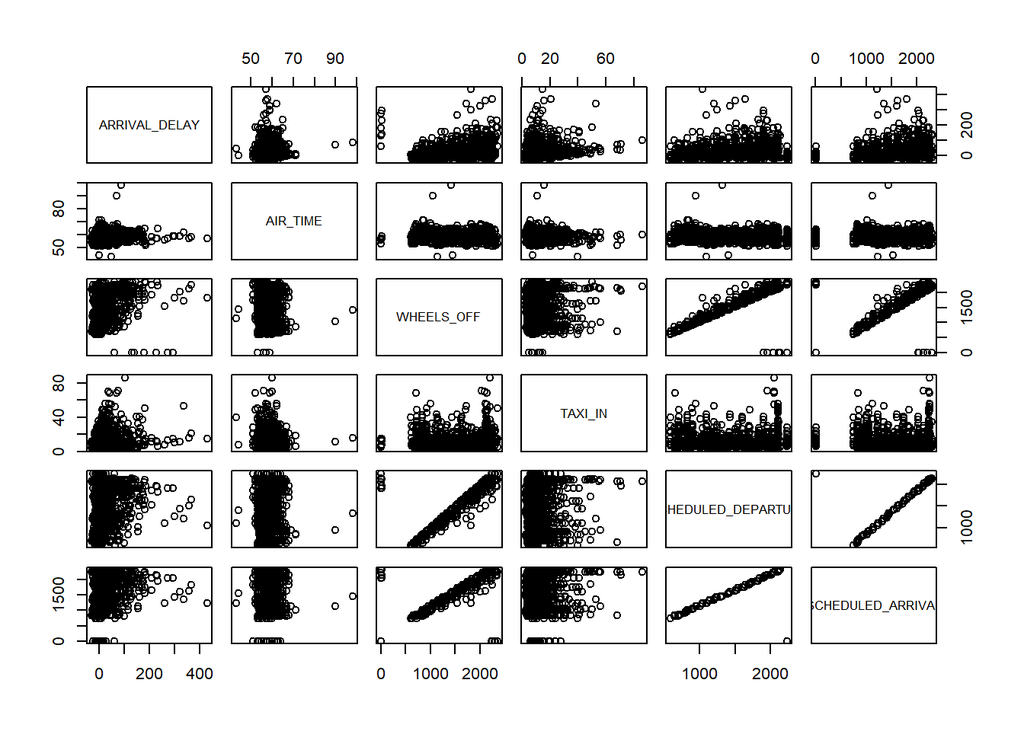

```r
pairs(~ .,data = Data_Subset)
```

```r
Data_Train <- Data_Subset[0:955, ]
Data_Test <- Data_Subset[0:408, ]
```

Multiple Linear Regression

```r
LMmodel<- lm(ARRIVAL_DELAY ~., data = Data_Train)
summary(LMmodel)
```

```
##
## Call:
## lm(formula = ARRIVAL_DELAY ~ ., data = Data_Train)
##
## Residuals:
##     Min      1Q  Median      3Q     Max
## -74.600 -25.191 -11.716   9.405 315.725
##
## Coefficients:
##                       Estimate Std. Error t value Pr(>|t|)
## (Intercept)         -63.051842  26.989599  -2.336   0.0197 *
## AIR_TIME              0.502733   0.446800   1.125   0.2608
## WHEELS_OFF            0.020512   0.008244   2.488   0.0130 *
## TAXI_IN               0.955469   0.170017   5.620 2.54e-08 ***
## SCHEDULED_DEPARTURE  -0.010939   0.009501  -1.151   0.2499
## SCHEDULED_ARRIVAL     0.020635   0.004392   4.698 3.04e-06 ***
## ---
## Signif. codes:  0 '***' 0.001 '**' 0.01 '*' 0.05 '.' 0.1 ' ' 1
##
## Residual standard error: 45.52 on 905 degrees of freedom
##   (44 observations deleted due to missingness)
## Multiple R-squared:  0.1266, Adjusted R-squared:  0.1218
## F-statistic: 26.24 on 5 and 905 DF,  p-value: < 2.2e-16
```

The confidence interval of the model coefficient can be extracted as below.

```r
confint(LMmodel)
```

```
##                             2.5 %        97.5 %
## (Intercept)         -1.160213e+02 -10.082358814
## AIR_TIME            -3.741520e-01   1.379617687
## WHEELS_OFF           4.332304e-03   0.036691392
## TAXI_IN              6.217958e-01   1.289142324
## SCHEDULED_DEPARTURE -2.958633e-02   0.007708194
## SCHEDULED_ARRIVAL    1.201482e-02   0.029255891
```